# Analyse du biais national dans le jugement en patinage artistique

Richard Florian

14 September 2026

# 1 Introduction

Le patinage artistique est un sport dans lequel une partie importante du résultat dépend de l’évaluation d’un panel de juges. Le pointage comprend des éléments techniques ainsi que des composantes du programme. Les éléments possèdent une valeur de base, à laquelle s’ajoute une évaluation de l’exécution, tandis que les composantes évaluent notamment des aspects artistiques. Une partie du pointage repose donc sur une appréciation subjective.

Cette subjectivité rend l’analyse statistique du jugement particulièrement intéressante. La question principale de ce projet est :

**Est-ce que les juges de patinage artistique évaluent plus favorablement les patineurs de leur propre pays ?**

L’hypothèse de départ est qu’un biais national peut être observé et que les juges accordent en moyenne des scores plus élevés aux patineurs représentant leur propre pays.

En complément, le projet explore la distribution des scores, les différences entre les programmes, la représentation géographique des participants et la variation de l’écart de notation selon la nationalité du juge et le programme.

# 2 Données

Les données utilisées proviennent du dépôt GitHub *figure-skating-scores* de BuzzFeed News. Elles ont été extraites à partir des protocoles publiés par l’International Skating Union (ISU). L’ensemble comprend 17 compétitions internationales de 2016 et 2017.

Les données originales sont réparties dans quatre fichiers CSV : `performances`, `judged_aspects`, `judge_scores` et `programs`. Ils permettent de relier les performances, les éléments ou composantes jugés, les scores individuels des juges et les programmes.

Une limite importante est l’absence de la nationalité des juges dans les données originales. Cette information est indispensable pour répondre à la question principale. Un fichier supplémentaire, `judges_info.csv`, a donc été construit manuellement. Comme cette collecte est longue, les informations ont été ajoutées pour trois compétitions :

- ISU World Figure Skating Championships 2017;
- ISU GP Trophee de France 2016;
- ISU Four Continents Championships 2017.

Les analyses portant directement sur le biais des juges sont donc limitées à ces trois compétitions. Les analyses qui ne nécessitent pas la nationalité des juges, notamment la carte du monde, peuvent utiliser l’ensemble des compétitions disponibles.

Un fichier `correspondance.csv` est aussi utilisé pour faire correspondre les codes de pays sportifs aux codes ISO nécessaires à la cartographie.

# 3 Importation et préparation des données

Le code R utilisé pour produire les analyses est conservé dans ce fichier R Markdown et dans le fichier `analyse.R` du dépôt GitHub. Afin de rendre le rapport HTML plus lisible, les blocs de code sont exécutés lors du *Knit*, mais ils ne sont pas affichés dans la version HTML. Les résultats, tableaux et graphiques produits par le code demeurent visibles.

Les tables sont fusionnées à l’aide de leurs clés communes. La table contenant la nationalité des juges est ajoutée à la fin. `df_full2` contient ainsi les observations pour lesquelles l’information sur les juges est disponible.

Dans les données détaillées, les scores sont enregistrés par élément ou composante et par juge. Ils sont additionnés afin d’obtenir un score total pour chaque combinaison de compétition, programme, juge et performance.

Ce total n’est pas exactement le score officiel du patineur. Dans le calcul officiel, certaines notes extrêmes du panel peuvent être écartées. Pour étudier un possible biais individuel, il est toutefois pertinent de conserver les scores attribués par chaque juge, y compris les valeurs élevées ou faibles.

Une variable binaire `same_country` est ensuite créée. Elle vaut `TRUE` lorsque le juge et le patineur représentent le même pays et `FALSE` dans le cas contraire.

# 4 Analyse exploratoire

## 4.1 Comparaison des moyennes

```
## [1] 41.71584
```

```
## [1] 46.68879
```

```
##   same_country    score
## 1        FALSE 41.71584
## 2         TRUE 46.68879
```

Dans les données finales, le score moyen est d’environ **41,72** lorsque le juge et le patineur représentent des pays différents et d’environ **46,69** lorsqu’ils représentent le même pays. L’écart brut est donc d’environ **4,97 points en faveur du même pays**.

Cette première comparaison va dans le sens de l’hypothèse, mais elle ne suffit pas à démontrer un biais. Certains pays peuvent notamment avoir de meilleurs patineurs. Des tests statistiques et un modèle tenant compte des nationalités sont donc nécessaires.

Les moyennes peuvent également être examinées séparément pour chacun des programmes.

```
##                  program same_country    score
## 1   ICE DANCE FREE DANCE        FALSE 50.45106
## 2  ICE DANCE SHORT DANCE        FALSE 41.41338
## 3    LADIES FREE SKATING        FALSE 41.34595
## 4   LADIES SHORT PROGRAM        FALSE 37.70443
## 5       MEN FREE SKATING        FALSE 43.35121
## 6      MEN SHORT PROGRAM        FALSE 39.24191
## 7     PAIRS FREE SKATING        FALSE 45.11960
## 8    PAIRS SHORT PROGRAM        FALSE 39.64568
## 9   ICE DANCE FREE DANCE         TRUE 55.31944
## 10 ICE DANCE SHORT DANCE         TRUE 47.33750
## 11   LADIES FREE SKATING         TRUE 44.32258
## 12  LADIES SHORT PROGRAM         TRUE 42.59615
## 13      MEN FREE SKATING         TRUE 48.00000
## 14     MEN SHORT PROGRAM         TRUE 43.51282
## 15    PAIRS FREE SKATING         TRUE 49.16406
## 16   PAIRS SHORT PROGRAM         TRUE 43.70139
```

# 5 Visualisation des données

## 5.1 Scores selon le biais national

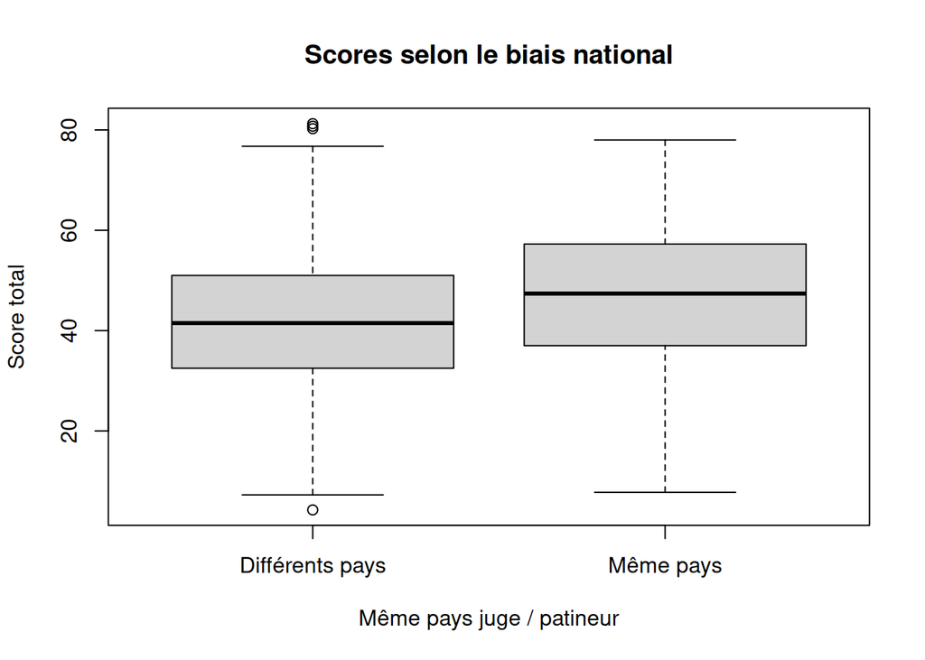

Ce boxplot a été choisi pour comparer la distribution des scores entre les deux groupes de la variable `same_country`. L’axe horizontal sépare les observations où le juge et le patineur représentent des pays différents de celles où ils représentent le même pays. L’axe vertical correspond au score total agrégé attribué par un juge à une performance.

La ligne au centre de chaque boîte représente la médiane, tandis que la boîte contient la moitié centrale des observations. On observe que la boîte et la médiane du groupe « Même pays » se situent plus haut que celles du groupe « Différents pays ». Le graphique suggère donc visuellement que les scores tendent à être plus élevés lorsque le juge et le patineur représentent le même pays. Cette observation reste cependant descriptive; le test t présenté plus loin permet de vérifier si la différence entre les moyennes est statistiquement significative.

## 5.2 Distribution des scores par programme

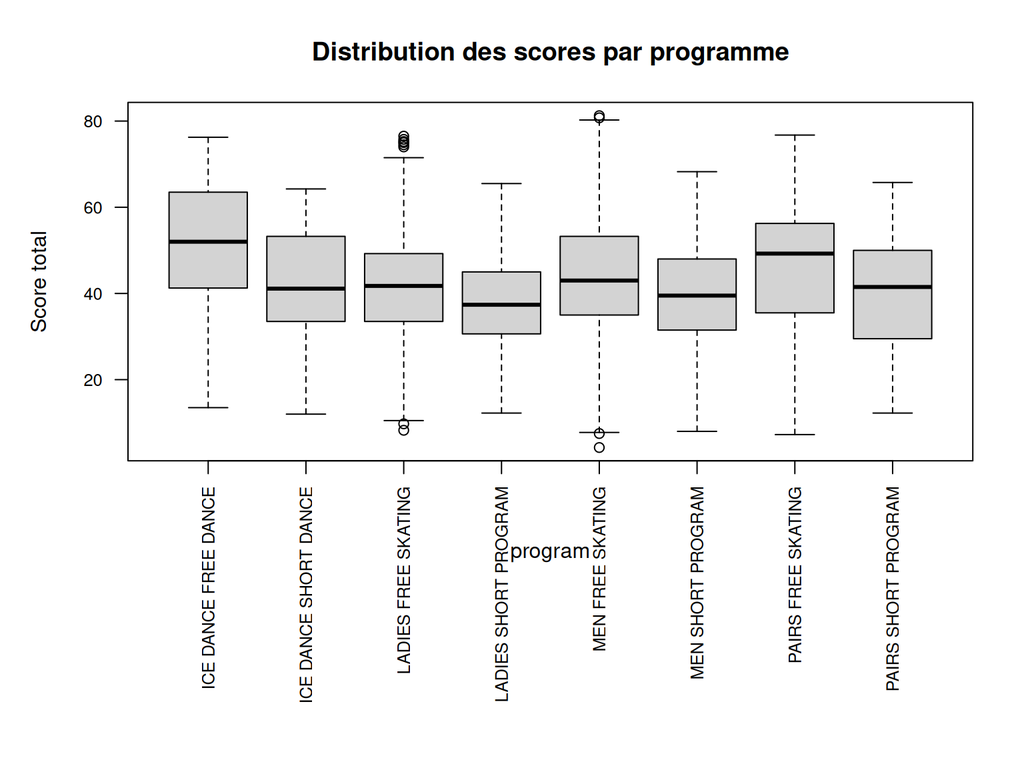

Ce boxplot permet de vérifier si les niveaux de scores sont comparables d’un programme à l’autre. L’axe horizontal présente les huit types de programmes, par exemple le programme court féminin, le programme libre masculin, les couples et la danse sur glace. L’axe vertical représente le score total agrégé.

Les positions des boîtes et des médianes ne sont pas identiques selon le programme. Certains programmes ont donc naturellement des scores plus élevés que d’autres. Cette visualisation est importante pour l’interprétation de l’analyse principale : une différence de score ne peut pas automatiquement être attribuée au biais national, puisque le type de programme influence également le niveau des scores. C’est aussi pour cette raison qu’une analyse distincte selon le programme est effectuée plus loin dans le rapport.

## 5.3 Distribution générale des scores

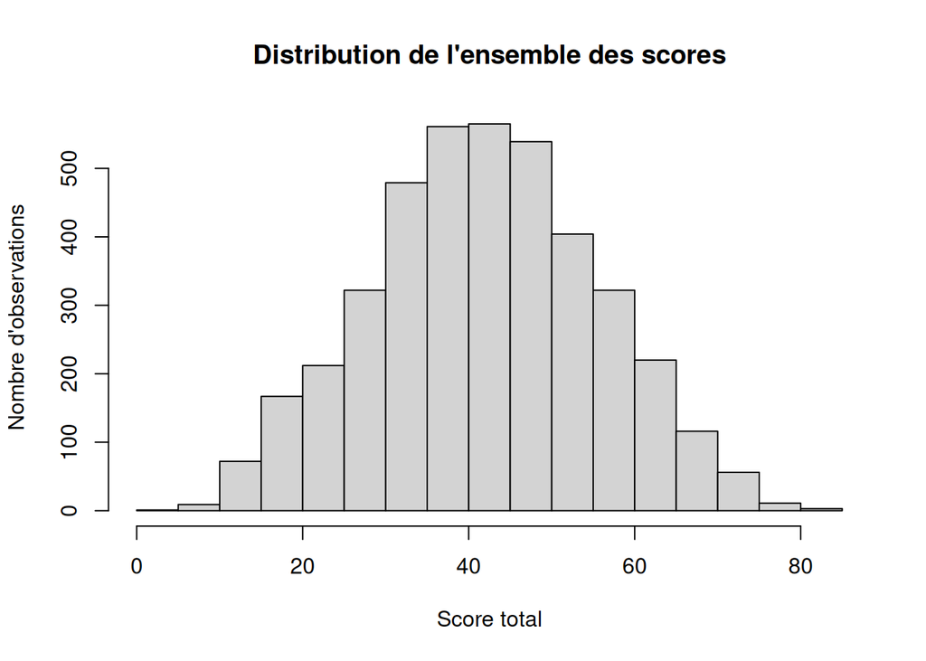

L’histogramme montre la distribution générale des scores agrégés dans `df_summary`. L’axe horizontal représente le score total, tandis que l’axe vertical indique le nombre d’observations dans chaque intervalle de scores.

La majorité des observations se situe dans la partie centrale de la distribution, avec moins d’observations aux valeurs très faibles ou très élevées. Le graphique permet donc de vérifier rapidement l’étendue des scores et leur forme générale avant d’effectuer les tests statistiques. Il permet aussi de constater qu’il n’y a pas seulement quelques valeurs isolées : les scores sont répartis sur un ensemble assez large de valeurs.

# 6 Tests de l’hypothèse principale

## 6.1 Pourquoi utiliser ces analyses?

Deux analyses principales sont utilisées pour répondre à la question de recherche, car elles répondent à deux questions légèrement différentes.

Le **test t de Welch** sert à comparer la moyenne d’une variable numérique entre deux groupes. Dans ce projet, la variable numérique est le `score` et les deux groupes sont définis par `same_country` : même pays ou pays différent. Il s’agit donc d’un choix directement adapté à la première question : *les deux groupes ont-ils des scores moyens différents?* La version de Welch est utilisée parce qu’elle ne suppose pas que les deux groupes possèdent exactement la même variance et qu’elle convient aussi lorsque les tailles des groupes sont différentes.

Le **modèle linéaire** est ensuite utilisé parce que le test t compare seulement les deux groupes sans contrôler d’autres variables. Or, le niveau des scores peut aussi varier selon la nationalité des patineurs ou celle des juges. Le modèle linéaire permet d’étudier l’association entre `same_country` et le score tout en tenant compte simultanément de ces autres variables.

Ces deux méthodes sont donc complémentaires : le test t mesure la différence brute entre les deux groupes, alors que le modèle linéaire permet de vérifier si une association avec `same_country` demeure lorsque d’autres facteurs sont considérés.

## 6.2 Test t de Welch

Le test t de Welch compare les scores moyens des observations où `same_country` est `TRUE` et `FALSE`. L’hypothèse nulle est qu’il n’existe pas de différence entre les deux moyennes.

```
##
##  Welch Two Sample t-test
##
## data:  score by same_country
## t = -5.7557, df = 330.06, p-value = 1.973e-08
## alternative hypothesis: true difference in means between group FALSE and group TRUE is not equal to 0
## 95 percent confidence interval:
##  -6.672615 -3.273292
## sample estimates:
## mean in group FALSE  mean in group TRUE
##            41.71584            46.68879
```

Avec les données finales, le test donne **t = -5,7557** et une **p-value d’environ 1,97 × 10^-8**. La p-value est largement inférieure à 0,05 : l’hypothèse nulle est rejetée. La différence entre les deux moyennes est statistiquement significative.

L’écart brut est d’environ 4,97 points. Cependant, le test t ne contrôle pas les différences entre les pays. Une partie de cet écart pourrait provenir du niveau des patineurs ou de la composition de l’échantillon.

## 6.3 Modèle linéaire

Un modèle linéaire cherche à représenter la relation entre une variable à expliquer et une ou plusieurs variables explicatives. Dans le cas le plus simple avec une seule variable, on peut l’écrire sous la forme **y = ax + b**. `y` est la valeur que l’on cherche à expliquer, `x` est la variable explicative, `a` représente l’effet associé à cette variable et `b` est la valeur de départ, appelée constante ou intercept.

Dans ce projet, le principe est le même, mais plusieurs variables explicatives sont utilisées en même temps. Le modèle peut être représenté de façon simplifiée ainsi :

**score = constante + effet de la nationalité du juge + effet de la nationalité du patineur + effet de same_country + erreur**

Le `score` est donc la variable à expliquer. `judge_nation`, `nation` et `same_country` sont les variables utilisées pour expliquer une partie des différences de score. Comme les nationalités sont des variables catégorielles, R crée automatiquement des coefficients pour comparer leurs différentes catégories à une catégorie de référence.

L’intérêt principal du modèle pour cette recherche est le coefficient de `same_countryTRUE`. Il représente la différence moyenne associée au fait que le juge et le patineur représentent le même pays **après avoir tenu compte** des différences générales liées à la nationalité du juge et à la nationalité du patineur.

```
##
## Call:
## lm(formula = score ~ judge_nation + nation + same_country, data = df_summary)
##
## Residuals:
##     Min      1Q  Median      3Q     Max
## -33.504  -6.521   0.108   6.066  34.761
##
## Coefficients:
##                  Estimate Std. Error t value Pr(>|t|)
## (Intercept)       27.4595     1.5032  18.268  < 2e-16 ***
## judge_nationAUT    4.2697     1.0799   3.954 7.83e-05 ***
## judge_nationBEL    2.5710     1.4615   1.759 0.078625 .
## judge_nationBLR    4.4826     1.4172   3.163 0.001574 **
## judge_nationBUL    1.6750     1.8618   0.900 0.368355
## judge_nationCAN    2.3809     0.8620   2.762 0.005769 **
## judge_nationCHN    1.6643     0.9032   1.843 0.065437 .
## judge_nationCZE    3.8065     0.9896   3.846 0.000122 ***
## judge_nationDEN   -1.6929     1.6288  -1.039 0.298728
## judge_nationESP    4.8572     1.0025   4.845 1.31e-06 ***
## judge_nationFRA    3.0362     0.9814   3.094 0.001990 **
## judge_nationGBR    4.8388     1.1379   4.252 2.16e-05 ***
## judge_nationGER    3.4440     1.0888   3.163 0.001572 **
## judge_nationISR    4.4648     1.1578   3.856 0.000117 ***
## judge_nationITA    4.0677     1.2627   3.222 0.001285 **
## judge_nationJPN    1.5011     0.8737   1.718 0.085858 .
## judge_nationKAZ    3.8584     1.3423   2.874 0.004068 **
## judge_nationKOR    4.4007     0.9353   4.705 2.62e-06 ***
## judge_nationLAT    6.2811     2.1191   2.964 0.003054 **
## judge_nationLTU    9.5149     2.5540   3.726 0.000198 ***
## judge_nationMEX    0.7759     1.2868   0.603 0.546552
## judge_nationNOR    2.5465     1.4379   1.771 0.076646 .
## judge_nationNZL    1.3509     1.2868   1.050 0.293861
## judge_nationRSA   -4.3989     1.6284  -2.701 0.006936 **
## judge_nationRUS    4.0931     0.9424   4.343 1.44e-05 ***
## judge_nationSLO    4.7004     2.1196   2.218 0.026640 *
## judge_nationSUI    3.2333     1.2521   2.582 0.009847 **
## judge_nationSWE    6.6796     2.1196   3.151 0.001637 **
## judge_nationTPE    0.4343     1.2146   0.358 0.720691
## judge_nationTUR    5.9963     1.8747   3.198 0.001392 **
```

[output cut: 39 more lines]

```
## nationSUI         -6.8456     2.3134  -2.959 0.003104 **
## nationSVK          5.2033     2.6752   1.945 0.051839 .
## nationSWE          5.5605     2.3147   2.402 0.016341 *
## nationTPE         -5.1825     1.7788  -2.914 0.003594 **
## nationTUR         10.1464     2.6731   3.796 0.000149 ***
## nationUKR          8.1859     1.8914   4.328 1.54e-05 ***
## nationUSA         19.8299     1.4140  14.024  < 2e-16 ***
## nationUZB         16.3815     1.8961   8.640  < 2e-16 ***
## same_countryTRUE   3.0638     0.6104   5.019 5.42e-07 ***
## ---
## Signif. codes:  0 '***' 0.001 '**' 0.01 '*' 0.05 '.' 0.1 ' ' 1
##
## Residual standard error: 9.799 on 3981 degrees of freedom
## Multiple R-squared:  0.4892, Adjusted R-squared:  0.4793
## F-statistic: 49.51 on 77 and 3981 DF,  p-value: < 2.2e-16
```

Dans le modèle final, le coefficient associé à `same_countryTRUE` est d’environ **+3,06 points**, avec une **p-value d’environ 5,42 × 10^-7**. Cela signifie que, toutes les autres variables présentes dans ce modèle étant considérées, les observations où le juge et le patineur représentent le même pays sont associées à un score moyen d’environ 3,06 points plus élevé.

Le modèle possède un **R² d’environ 0,489**. Le R² indique la proportion de la variation totale des scores qui est expliquée par les variables du modèle. Ici, environ 49 % de la variation observée est expliquée par la nationalité du juge, la nationalité du patineur et `same_country`.

Le fait que l’écart estimé par le modèle (+3,06) soit plus faible que l’écart brut du test t (+4,97) suggère qu’une partie de la différence initialement observée est liée à la composition des nationalités dans les données. Malgré ce contrôle, l’association avec `same_country` demeure positive et statistiquement significative.

# 7 Écart selon la nationalité du juge

Une analyse descriptive permet ensuite de vérifier si l’écart est semblable pour toutes les nationalités de juges. Pour chaque nationalité, le score moyen attribué aux patineurs du même pays est comparé au score moyen attribué aux autres pays.

```
##    judge_nation same_country_meme_pays score_meme_pays same_country_autre_pays
## 15          KAZ                   TRUE        64.37500                   FALSE
## 5           CAN                   TRUE        55.10976                   FALSE
## 25          USA                   TRUE        52.56548                   FALSE
## 12          ISR                   TRUE        54.45000                   FALSE
## 6           CHN                   TRUE        49.99107                   FALSE
## 8           ESP                   TRUE        55.14286                   FALSE
## 20          RUS                   TRUE        54.16346                   FALSE
## 11          GER                   TRUE        52.89286                   FALSE
## 3           BEL                   TRUE        48.75000                   FALSE
## 26          UZB                   TRUE        48.25000                   FALSE
## 14          JPN                   TRUE        46.14286                   FALSE
## 9           FRA                   TRUE        45.96429                   FALSE
## 23          TUR                   TRUE        47.50000                   FALSE
## 13          ITA                   TRUE        43.55000                   FALSE
```

[output cut: 39 more lines]

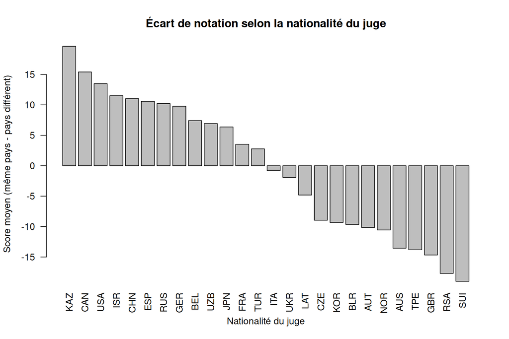

Dans ce graphique, chaque barre correspond à une nationalité de juge. L’axe vertical représente la différence entre le score moyen donné aux patineurs du même pays que le juge et le score moyen donné aux patineurs des autres pays. Une valeur positive signifie donc que, pour cette nationalité, les compatriotes ont reçu en moyenne un score plus élevé. Une valeur négative signifie l’inverse.

Le graphique montre une variation importante selon la nationalité du juge. Certaines nationalités présentent un écart positif marqué, tandis que d’autres présentent un écart négatif. La tendance générale n’est donc pas uniforme.

Cette analyse est **descriptive**. Un grand écart ne signifie pas automatiquement qu’une nationalité est « plus biaisée », puisque le nombre d’observations, les patineurs évalués et leur niveau peuvent varier d’un pays à l’autre. Le graphique sert surtout à montrer que l’effet moyen observé dans l’ensemble des données peut cacher des différences entre les groupes.

# 8 Représentation géographique des participants

Cette section utilise `df_full`, donc l’ensemble des compétitions disponibles, puisque la nationalité des juges n’est pas nécessaire. Un même participant pouvant apparaître dans plusieurs compétitions, chaque combinaison unique de nom et de nationalité est comptée une seule fois.

## 8.1 Carte du monde

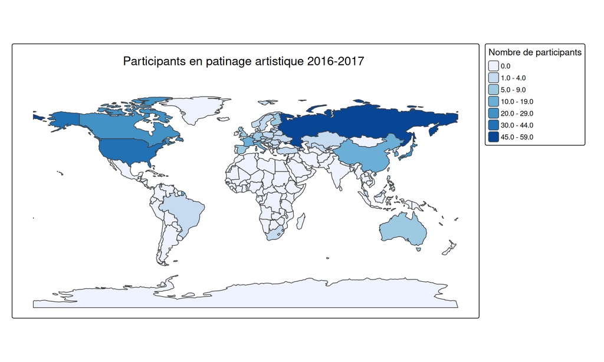

La carte représente le nombre de participants uniques associés à chaque pays dans les 17 compétitions disponibles. Plus la classe de couleur est élevée, plus le nombre de participants provenant du pays est important. L’objectif de cette visualisation n’est pas de mesurer directement le biais, mais de montrer la composition géographique de l’ensemble de données.

La représentation est très inégale. La Russie est particulièrement présente, tout comme les États-Unis, le Canada et le Japon. Plusieurs autres pays apparaissent dans les données avec beaucoup moins de participants. Cette différence de représentation est importante à garder en tête, car les pays les plus présents génèrent davantage d’observations et davantage d’occasions pour un juge d’évaluer un patineur de son propre pays.

## 8.2 Tableau du nombre de participants par pays

```
##                        Pays Nombre de participants
## 1                    Russia                     58
## 2  United States of America                     36
## 3                    Canada                     25
## 4                     Japan                     25
## 5                     China                     16
## 6               South Korea                     14
## 7                    France                     11
## 8                     Italy                     11
## 9                 Australia                      9
## 10                  Germany                      8
## 11                   Israel                      7
## 12                  Czechia                      6
## 13           United Kingdom                      6
## 14                    Spain                      5
```

[output cut: 33 more lines]

Le tableau montre que la Russie compte **58 participants uniques**, devant les États-Unis (**36**), le Canada et le Japon (**25 chacun**). La Chine compte 16 participants et la Corée du Sud 14. La représentation diminue ensuite rapidement.

Cette répartition est utile pour contextualiser l’analyse du biais : les pays ne sont pas représentés également dans les données et les occasions pour un juge d’évaluer un compatriote ne sont donc pas nécessairement les mêmes pour toutes les nationalités.

# 9 Écart de notation selon le programme

Une dernière analyse descriptive vérifie si l’écart « même pays - pays différent » apparaît seulement dans certains programmes ou de façon plus générale.

```
##                  program same_country    score
## 1   ICE DANCE FREE DANCE        FALSE 50.45106
## 2  ICE DANCE SHORT DANCE        FALSE 41.41338
## 3    LADIES FREE SKATING        FALSE 41.34595
## 4   LADIES SHORT PROGRAM        FALSE 37.70443
## 5       MEN FREE SKATING        FALSE 43.35121
## 6      MEN SHORT PROGRAM        FALSE 39.24191
## 7     PAIRS FREE SKATING        FALSE 45.11960
## 8    PAIRS SHORT PROGRAM        FALSE 39.64568
## 9   ICE DANCE FREE DANCE         TRUE 55.31944
## 10 ICE DANCE SHORT DANCE         TRUE 47.33750
## 11   LADIES FREE SKATING         TRUE 44.32258
## 12  LADIES SHORT PROGRAM         TRUE 42.59615
## 13      MEN FREE SKATING         TRUE 48.00000
## 14     MEN SHORT PROGRAM         TRUE 43.51282
## 15    PAIRS FREE SKATING         TRUE 49.16406
## 16   PAIRS SHORT PROGRAM         TRUE 43.70139
```

```
##                 program same_country_meme score_meme same_country_autre
## 2 ICE DANCE SHORT DANCE              TRUE   47.33750              FALSE
## 4  LADIES SHORT PROGRAM              TRUE   42.59615              FALSE
## 1  ICE DANCE FREE DANCE              TRUE   55.31944              FALSE
## 5      MEN FREE SKATING              TRUE   48.00000              FALSE
## 6     MEN SHORT PROGRAM              TRUE   43.51282              FALSE
## 8   PAIRS SHORT PROGRAM              TRUE   43.70139              FALSE
## 7    PAIRS FREE SKATING              TRUE   49.16406              FALSE
## 3   LADIES FREE SKATING              TRUE   44.32258              FALSE
##   score_autre    ecart
## 2    41.41338 5.924118
## 4    37.70443 4.891720
## 1    50.45106 4.868386
## 5    43.35121 4.648785
## 6    39.24191 4.270911
## 8    39.64568 4.055710
## 7    45.11960 4.044461
## 3    41.34595 2.976626
```

L’écart est positif dans **les huit programmes étudiés**. Il varie d’environ **+2,98 points** pour le programme libre féminin à environ **+5,92 points** pour la danse courte. La différence générale observée n’est donc pas produite uniquement par un programme particulier.

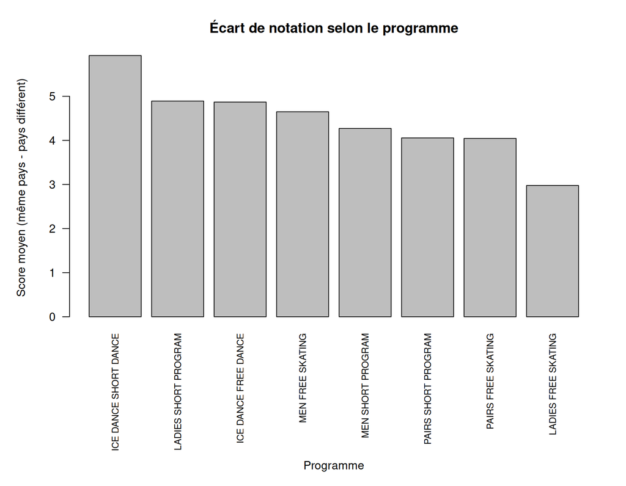

Le graphique présente directement cet écart pour chaque programme. L’axe vertical correspond à la différence « score moyen même pays - score moyen pays différent ». Une barre au-dessus de zéro indique donc un score moyen plus élevé lorsque le juge et le patineur représentent le même pays.

Toutes les barres sont positives. L’écart varie selon le programme, mais la direction de l’effet demeure la même dans les huit cas. Ce résultat est intéressant parce qu’il montre que la tendance générale n’est pas uniquement causée par un seul type de programme.

Cette comparaison reste descriptive : elle montre la direction et l’ampleur des écarts, mais elle ne constitue pas huit tests distincts démontrant que chaque différence est statistiquement significative.

# 10 Discussion

Les différentes analyses convergent vers le même constat. La comparaison descriptive montre d’abord que les scores sont plus élevés lorsque le juge et le patineur représentent le même pays. Le test t de Welch indique ensuite que cette différence globale est statistiquement significative. Enfin, le modèle linéaire montre que l’association demeure significative après avoir pris en considération la nationalité du juge et celle du patineur.

Le modèle linéaire est particulièrement utile pour l’interprétation. L’écart brut est d’environ 4,97 points, alors que l’effet estimé de `same_country` dans le modèle est d’environ 3,06 points. Cette diminution montre qu’une partie de la différence brute peut être associée à la composition des pays présents dans les données. Malgré cela, un effet positif lié au même pays demeure.

Les analyses complémentaires montrent que le phénomène n’est pas parfaitement uniforme : l’écart varie selon la nationalité du juge. Il reste cependant positif lorsqu’on examine séparément chacun des huit programmes. La carte et le tableau montrent également que les pays sont représentés de manière très inégale dans l’ensemble des compétitions.

# 11 Limites

La principale limite concerne la nationalité des juges. Cette information n’était pas incluse dans les fichiers originaux et a dû être ajoutée manuellement. L’analyse du biais porte donc sur trois compétitions seulement, même si la base originale en contient 17. Les résultats indiquent une tendance dans l’échantillon étudié, mais ne permettent pas d’affirmer que le même effet existe avec la même ampleur dans toutes les compétitions internationales.

Une deuxième limite concerne le score utilisé. Les scores attribués par chaque juge sont additionnés afin de conserver l’information individuelle. Ce score agrégé diffère du score officiel, puisque le calcul officiel du panel peut écarter certaines notes extrêmes. Cette différence est volontaire pour la question étudiée, mais elle doit être prise en compte.

Le modèle contrôle la nationalité du juge et du patineur, mais il ne tient pas nécessairement compte de tous les facteurs susceptibles d’influencer les scores, comme le niveau individuel du patineur, la difficulté précise du programme, la compétition ou d’autres caractéristiques de la performance.

Enfin, les analyses par nationalité de juge et par programme sont descriptives. Elles permettent d’identifier des tendances, mais les différences entre toutes les sous-catégories n’ont pas fait l’objet de tests statistiques distincts.

# 12 Conclusion

L’objectif principal était de déterminer si les juges de patinage artistique évaluent plus favorablement les patineurs de leur propre pays. Les résultats obtenus soutiennent cette hypothèse dans les données étudiées.

Le score moyen est plus élevé lorsque le juge et le patineur représentent le même pays. Cette différence est statistiquement significative selon le test t de Welch. Elle demeure également significative dans le modèle linéaire après la prise en compte de la nationalité du juge et du patineur, avec un effet estimé d’environ trois points supplémentaires lorsque les deux nationalités correspondent.

Les analyses complémentaires montrent que l’ampleur de l’écart varie selon la nationalité du juge, mais que l’écart reste positif dans chacun des huit programmes étudiés. La représentation géographique montre aussi que certains pays, particulièrement la Russie, les États-Unis, le Canada et le Japon, sont beaucoup plus présents dans les compétitions de la base de données.

Il est donc possible de conclure qu’il existe, dans l’échantillon analysé, une association statistiquement significative entre le fait qu’un juge et un patineur représentent le même pays et le score accordé. En raison des limites de l’échantillon et des autres facteurs pouvant influencer les scores, ce résultat doit toutefois être interprété comme une indication de favoritisme national plutôt que comme une preuve définitive de causalité.